# Linear gemischte Modelle zur Analyse von WHO Key Health Indicators

L. Bartsch

6 April 2019

### Fragestellung: Gibt es einen Zusammenhang zwischen den Gesundheitsausgaben eines Landes und der durchschnittlichen Lebenserwartung?

Für die Untersuchung wurden ausgesuchte Angaben aus dem Bericht der World Health Organisation: Core Health Indicators of WHO European Region 2017 genutzt. Die Untersuchung der Fragestellung wird anhand des R-Scriptes in diesem Dokument durchgeführt:

#### Einlesen der Daten

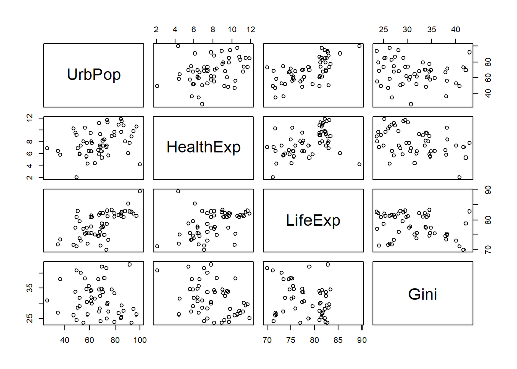

```r
rawData <- read.csv2('selected_WHO_Data.csv', sep = ';')
# reset long column names
longColumnNames <- colnames(rawData) # save long ones for later use
colnames(rawData) <- c("Country",
                       "UrbPop", # Urban Population Rate
                       "HealthExp", # estimates Health Expentiture as % from GDP
                       "LifeExp", # Life Expectancy for both sex
                       "Gini") # Gini Index
#  first plot
library(ggplot2)
scattermatrix <- pairs(rawData[,2:5])
```

#### Kennwerte der Quelldaten

```
##        Country       UrbPop         HealthExp         LifeExp
##  Albania   : 1   Min.   : 26.30   Min.   : 2.100   Min.   :70.00
##  Andorra   : 1   1st Qu.: 57.55   1st Qu.: 6.400   1st Qu.:75.20
##  Armenia   : 1   Median : 68.25   Median : 7.800   Median :78.90
##  Austria   : 1   Mean   : 67.75   Mean   : 7.904   Mean   :78.56
##  Azerbaijan: 1   3rd Qu.: 78.90   3rd Qu.: 9.575   3rd Qu.:82.20
##  Belarus   : 1   Max.   :100.00   Max.   :11.900   Max.   :89.50
##  (Other)   :48                                     NA's   :1
##       Gini
##  Min.   :23.60
##  1st Qu.:27.00
##  Median :30.60
##  Mean   :31.33
##  3rd Qu.:34.50
##  Max.   :42.80
##  NA's   :3
```

#### Fehlende Werte ersetzen

Man sieht die Kennzahlen für die Variablen, sowie die Anzahl der nicht vorhandenen Einträge pro Spalte. Als nächstes wird die relative Häufigkeit der fehlenden Werte pro Variable berechnet. Vor allem für kleine Länder (Andorra, San Marino und Monaco) fehlen Werte für den Gini Index.

```r
# missing values MCAR -> fix missing using MICE
pMiss <- function(x){sum(is.na(x))/length(x)*100}
apply(rawData,2,pMiss) # Carefull: Gini Index have 5.5% NA
```

```
##   Country    UrbPop HealthExp   LifeExp      Gini
##  0.000000  0.000000  0.000000  1.851852  5.555556
```

5,5% der Werte für den Gini Index fehlen. Diese relativ hohe Anzahl an NA Werten, kann sich auf die Qualität der anschließenden Analysen negativ auswirken. Mit dem mice package (*Multiple Imputations by Chained Equations*) werden plausible synthetische Daten für die fehlenden Werte in Abhängigkeit aller Spalten des Datensatzes, berechnet. Das konkrete Verfahren das hier genutzt wurde, ist das predictive mean matching.

```r
library(mice)
library(lattice)
# use predictive mean matching from mice package for handling NA values
tempData <- invisible(mice(rawData,
                 m = 5, # number of datasets to compute
                 maxit = 50,
                 meth = 'pmm',
                 seed = 42,
                 printflat = FALSE))
completeData = complete(tempData, 1)
```

```
##        Country       UrbPop         HealthExp         LifeExp
##  Albania   : 1   Min.   : 26.30   Min.   : 2.100   Min.   :70.00
##  Andorra   : 1   1st Qu.: 57.55   1st Qu.: 6.400   1st Qu.:75.25
##  Armenia   : 1   Median : 68.25   Median : 7.800   Median :79.25
##  Austria   : 1   Mean   : 67.75   Mean   : 7.904   Mean   :78.61
##  Azerbaijan: 1   3rd Qu.: 78.90   3rd Qu.: 9.575   3rd Qu.:82.10
##  Belarus   : 1   Max.   :100.00   Max.   :11.900   Max.   :89.50
##  (Other)   :48
##       Gini
##  Min.   :23.60
##  1st Qu.:27.20
##  Median :30.25
##  Mean   :31.20
##  3rd Qu.:34.45
##  Max.   :42.80
##
```

```
## Standard Deviation Gini Index before fixing missing values:  5.300909
##  Standard Deviation Gini Index after fixing missing values:  5.177054
```

Ein Blick auf die Kennwerte zeigt, dass sich Kennwerte, wie *Mittelwerte* oder die *Standard Abweichung*, nach dem Ersetzen der fehlenden Werte kaum geändert haben.  
Jedoch muss hier angemerkt werden, dass die Methode aus dem *mice* package mehrere Werte pro *NA* generiert. In diesem Beispiel wurden willkürlich Daten gewählt. Für eine gründliche Analyse müssten für jeden Satz generierter Werte alle der nachfolgenden Schritte berechnet werden. Der Modellfehler der durch das Ersetzen der *NA* Werte entsteht, kann dann über die Residuen abgeschätzt werden.

#### Ausreißer

Nun wird überprüft inwiefern der Datensatz Ausreißer enthält. Dafür wird die Mahalanobis Entfernung genutzt.

```r
# outlier check using mahalanobis distance
mahal = mahalanobis(completeData[, -c(1)],
                    colMeans(completeData[, -c(1)]),
                    cov(completeData[, -c(1)], use = "pairwise.complete.obs")) # mahalanobis distance for all data points
cutoff = qchisq(1 - .001, ncol(completeData[, -c(1)])) # cutoff for 99.999% of all datapoints
summary(mahal < cutoff)
```

```
##    Mode    TRUE
## logical      54
```

```r
completeData = completeData[mahal < cutoff, ] #
```

Wie hier zu sehen ist, liegen für die obere Verteilung keine Ausreißer vor. (Für eine $\chi^{2}$ Funktion mit p = 99,99 wird Monaco, mit UrbPop = 100, allerdings als Ausreißer betrachtet).

#### Multikollinearität

Anschließend wird untersucht inwieweit Multikollinearität vorliegt, um zu schauen ob mehrere Werte die selbe Eigenschaft messen. Dafür werden die Korrelationskoeffizienten berechnet und betrachtet, ob hohe Koeffizienten (~0.9) vorhanden sind.

```r
corrCoef <- cor(completeData[, -c(1)])
symnum(corrCoef)
```

```
##           U H L G
## UrbPop    1
## HealthExp . 1
## LifeExp   . . 1
## Gini        .   1
## attr(,"legend")
## [1] 0 ' ' 0.3 '.' 0.6 ',' 0.8 '+' 0.9 '*' 0.95 'B' 1
```

Wie man hier sehen kann liegen keine Korrelationen mit Werten betragsmäßg größer 0.6 vor. Somit liegt keine Multikollinearität vor.

#### Modellerstellung

Nun kann das grundlegende Modell *m0* erstellt werden, dass davon ausgeht das die durchschnittliche Lebenserwartung vom Anteil der Gesundheitsausgaben eines Landes abhängt.  
Die Null Hypothese für *m0* $H_0^{m0}$ sagt somit aus, dass es keinen signifikaten Zusammenhang zwischen der durchschnittlichen Lebenserwartung und den Gesundheitsausgaben eines Landes gibt.

Ein weiteres Modell *m1* bezieht den Anteil der urbanen Bevölkerungsrate als Kovarianz mit in das Modell ein. Die Null Hypothese $H_0^{m1}$ nimmt dabei an, dass durch das Einbeziehen der urbanen Bevölkerungsverteilung keine Varianz im Modell *m0* erklärt werden kann.

Ein drittes Modell *mFull* bezieht sowohl die urbane Bevölkerungsverteilung als auch die Vermögensverteilung der jeweiligen Länder mit ein.  
$H_0^{mFull}$ wird hierbei von $H_0^{m1}$ übernommen, mit dem Zusatz das der Gini Index eines Landes ebenso wenig Varianz im Modell *m0* erklären kann.

Die drei Modelle werden anschließend miteinander verglichen um das beste dieser drei Modelle, ausgehend von den gegebenen Daten, zu bestimmen.

```r
# y ~ x ->
formula0 = LifeExp ~ HealthExp # predict life expectancy from health expendencies
formula1 = LifeExp ~ HealthExp + UrbPop # also use Urban Population Rate
formulaFull = LifeExp ~ HealthExp + UrbPop + Gini # now take Gini Index on top
```

Zuerst wird *m0*, das Modell ohne Korrekturen, betrachtet.

```r
# no covariates
m0 <- lm(formula0, data = completeData)
summary(m0)
```

```
##
## Call:
## lm(formula = formula0, data = completeData)
##
## Residuals:
##     Min      1Q  Median      3Q     Max
## -8.9145 -2.4425  0.3385  2.3393 13.9110
##
## Coefficients:
##             Estimate Std. Error t value Pr(>|t|)
## (Intercept)  71.9873     2.0522  35.078  < 2e-16 ***
## HealthExp     0.8376     0.2506   3.343  0.00154 **
## ---
## Signif. codes:  0 '***' 0.001 '**' 0.01 '*' 0.05 '.' 0.1 ' ' 1
##
## Residual standard error: 3.951 on 52 degrees of freedom
## Multiple R-squared:  0.1769, Adjusted R-squared:  0.161
## F-statistic: 11.17 on 1 and 52 DF,  p-value: 0.001544
```

$H_0^{m0}$ wird damit widerlegt und es existiert ein Zusammenhang zwischen der durchschnittlichen Lebenserwartung und den Gesundheitsausgaben.

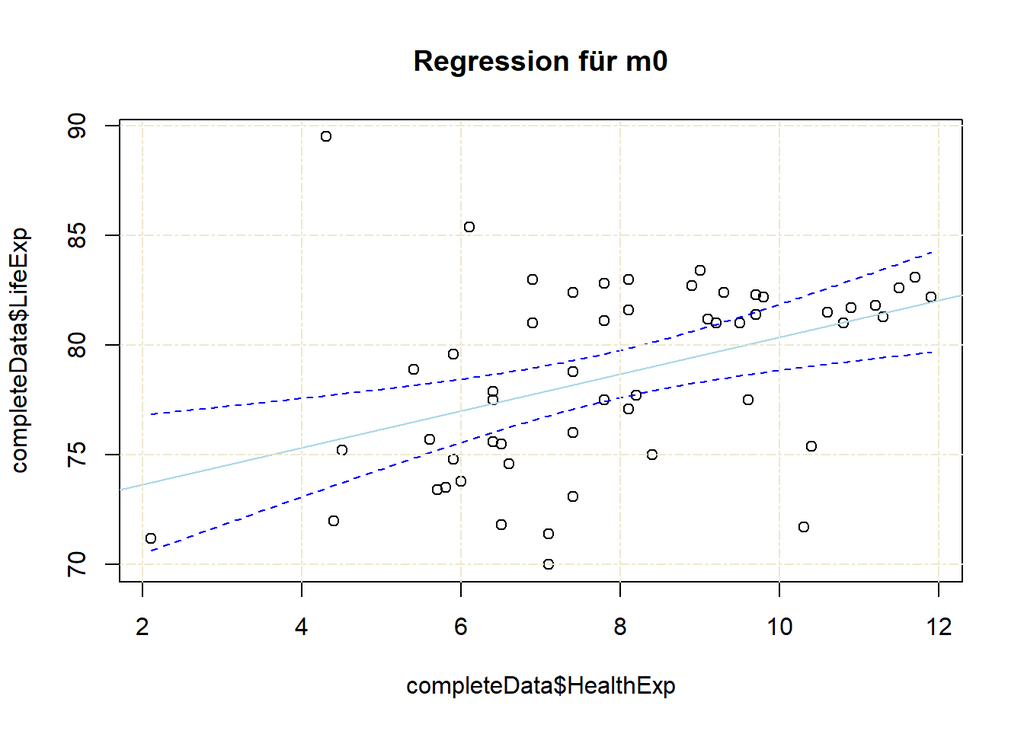

```r
# compute the models confidence interval and plot
newx = seq(min(completeData$HealthExp), max(completeData$HealthExp), by = 0.05)
conf_interval0 <- predict(m0, newdata=data.frame(HealthExp=newx), interval="confidence", level=0.95)
plot(completeData$HealthExp, completeData$LifeExp, main="Regression für m0")
abline(m0, col="lightblue")
lines(newx, conf_interval0[,2], col="blue", lty=2)
lines(newx, conf_interval0[,3], col="blue", lty=2)
grid (NULL,NULL, lty = 6, col = "cornsilk2")
```

#### Einschub: Normalverteilung prüfen

An dieser Stelle wird nun überprüft inwieweit die Daten normalverteilt sind. Dafür werden die Residuen des Modells *m0* auf Normalverteilung überprüft, unter der Annahme, dass die Daten auf denen das Modell beruht normalverteilt sind, wenn die Residuen des Modelles auch normal verteilt sind.

```r
# shapiro wilk test
shapiro.test(m0$residuals)
```

```
##
##  Shapiro-Wilk normality test
##
## data:  m0$residuals
## W = 0.96241, p-value = 0.08834
```

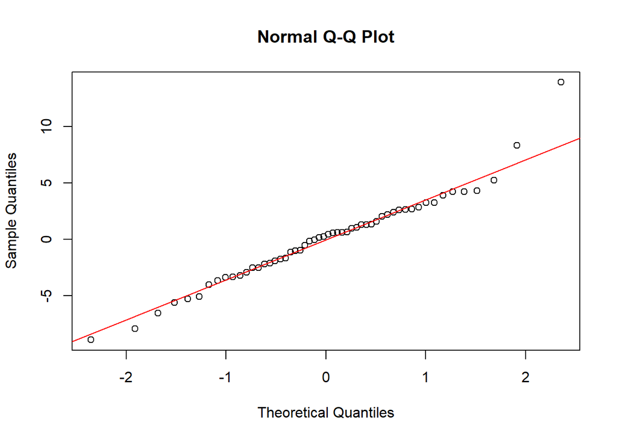

```r
normalDist = rnorm(length(m0$residuals))
# qqplot of risidual
qqnorm(m0$residuals);qqline(m0$residuals, col = 2)
```

In diesem Fall deutet der Shapiro-Wilk Test mit $p-value > 0.05$ darauf hin, das die Fehler und somit die Daten des Modelles nicht signifikant verschieden zu einer Normalverteilung sind. Im Quantil-Quantil Diagramm der Residuen kann zudem beobachtet werden, das der Modellfehler einer Normalverteilung folgt. Daraus kann nun geschlossen werden, dass auch die Daten, auf denen das Modell beruht, normal verteilt sind.

#### Modell m1

Nun wird Modell *m1* berechnet. Hierbei wird die urbane Bevölkerungsverteilung in die Lineare Regression miteinbezogen.

```r
# now with covariates
m1 = lm(formula1, data = completeData)
summary(m1)
```

```
##
## Call:
## lm(formula = formula1, data = completeData)
##
## Residuals:
##     Min      1Q  Median      3Q     Max
## -8.8791 -1.8634 -0.1872  1.6692  8.6863
##
## Coefficients:
##             Estimate Std. Error t value Pr(>|t|)
## (Intercept) 65.91798    2.33163  28.271  < 2e-16 ***
## HealthExp    0.52056    0.23286   2.236 0.029789 *
## UrbPop       0.12657    0.03095   4.089 0.000154 ***
## ---
## Signif. codes:  0 '***' 0.001 '**' 0.01 '*' 0.05 '.' 0.1 ' ' 1
##
## Residual standard error: 3.462 on 51 degrees of freedom
## Multiple R-squared:  0.3801, Adjusted R-squared:  0.3558
## F-statistic: 15.64 on 2 and 51 DF,  p-value: 5.056e-06
```

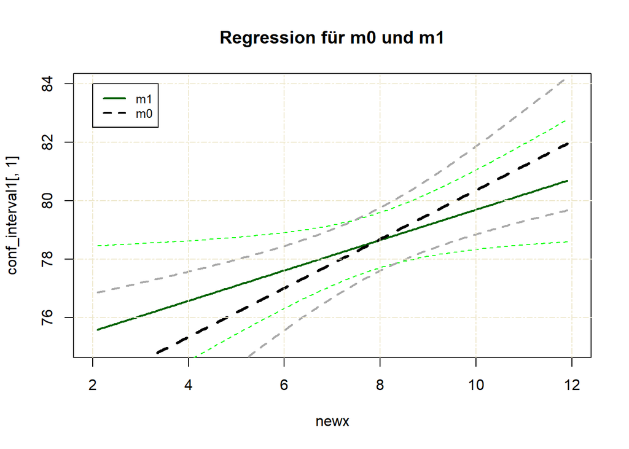

```r
#plot(completeData$HealthExp, completeData$Lifeexp, main="Regression")
#abline(m1, col="lightblue")
# compute the models confidence interval and plot
newx = seq(min(completeData$HealthExp), max(completeData$HealthExp), by = 0.05)
conf_interval1 <- predict(m1, newdata=data.frame(HealthExp=newx, UrbPop=mean(completeData$UrbPop)), interval="confidence", level=0.95)
#plot(completeData$HealthExp, completeData$Lifeexp, main="Regression")
#abline(mFull, col="lightblue")
plot(newx, conf_interval1[,1], col="darkgreen", type = 'l', lty=1, lwd = 2, xlim=c(2, 12), ylim=c(75, 84), main="Regression für m0 und m1")
lines(newx, conf_interval1[,2], col="green", lty=2)
lines(newx, conf_interval1[,3], col="green", lty=2)


lines(newx, conf_interval0[,1], col = "black", lty = 2, lwd = 3)
lines(newx, conf_interval0[,2], col = "darkgray", lty = 2, lwd = 2)
lines(newx, conf_interval0[,3], col = "darkgray", lty = 2, lwd = 2)
grid (NULL,NULL, lty = 6, col = "cornsilk2")
legend(2, 84, legend = c("m1", "m0"),
       col = c("darkgreen", "black"), lwd = 2, lty = 1:2, cex = 0.8)
```

*m1* zeigt nun für die Erhöhung der Gesundheitsausgaben einen geringeren Effekt auf die Lebenserwartung.  
Allgemein haben Modelle mit mehr Variablen die Tendenz Daten besser zu beschreiben. Bei *m1* könnte es sich hierbei jedoch um Overfitting handeln. Mittels AIC (*Akaike Information Criterion*) kann die Güte der Modell bewertet und verglichen werden. Der AIC bezieht dabei den erhöhten Freiheitsgrad des Modelles *m1* mit ein. Man erhält dadurch ein Gütekriterium das diesem Umstand mitbetrachtet. Kleinere Werte des AIC deuten hierbei auf eine höhere Modellgüte hin.

#### Vergleich der Modelle m0 und m1.

```r
# Calculate AIC
AIC(m0)
```

```
## [1] 305.5895
```

```r
AIC(m1)
```

```
## [1] 292.2751
```

```r
# test if with covariates is any better
summary(m1)
```

```
##
## Call:
## lm(formula = formula1, data = completeData)
##
## Residuals:
##     Min      1Q  Median      3Q     Max
## -8.8791 -1.8634 -0.1872  1.6692  8.6863
##
## Coefficients:
##             Estimate Std. Error t value Pr(>|t|)
## (Intercept) 65.91798    2.33163  28.271  < 2e-16 ***
## HealthExp    0.52056    0.23286   2.236 0.029789 *
## UrbPop       0.12657    0.03095   4.089 0.000154 ***
## ---
## Signif. codes:  0 '***' 0.001 '**' 0.01 '*' 0.05 '.' 0.1 ' ' 1
##
## Residual standard error: 3.462 on 51 degrees of freedom
## Multiple R-squared:  0.3801, Adjusted R-squared:  0.3558
## F-statistic: 15.64 on 2 and 51 DF,  p-value: 5.056e-06
```

```r
anova(m0, m1)
```

```
## Analysis of Variance Table
##
## Model 1: LifeExp ~ HealthExp
## Model 2: LifeExp ~ HealthExp + UrbPop
##   Res.Df    RSS Df Sum of Sq      F    Pr(>F)
## 1     52 811.64
## 2     51 611.22  1    200.42 16.723 0.0001537 ***
## ---
## Signif. codes:  0 '***' 0.001 '**' 0.01 '*' 0.05 '.' 0.1 ' ' 1
```

Durch die Änderung des Modelles, mit dem Einbezug der urbanen Bevölkerungsrate, kann Varianz in den Daten besser beschrieben werden ($r^{2}_{m1} = 0.38$ verglichen mit $r^{2}_{m0} = 0.17$). Somit kann angenommen werden das, dass Modell *m1* den Zusammenhang zwischen den Gesundheitsausgaben und der Lebenserwartung genauer beschreibt als das Modell *m0*. Der Einfluss der Gesundheitsausgaben auf die Lebenserwartung fällt also geringer aus, als durch das Modell *m0* vorhergesagt. Sowohl die ANOVA als auch der AIC weisen auf ein Modell hin, dass über eine größere Güte verfügt und die Varianz der vorliegenden Daten besser erklärt.

$H_0^{m1}$ wird somit verworfen, da der Effekt der urbane Bevölkerungsverteilung auf den Zusammenhang zwischen durchschnittlicher Lebenserwartung und Gesundheitsausgaben genauer beschreibt als das Modell *m0*.

#### Modell mFull

Nun wird das Modell, dass sowohl die Bevölkerungsverteilung als auch den Gini-Index berücksichtigt, betrachtet.

```r
# now with two covariates
mFull = lm(formulaFull, data = completeData)
summary(mFull)
```

```
##
## Call:
## lm(formula = formulaFull, data = completeData)
##
## Residuals:
##     Min      1Q  Median      3Q     Max
## -7.8401 -1.8685 -0.2992  2.2041  8.2199
##
## Coefficients:
##             Estimate Std. Error t value Pr(>|t|)
## (Intercept) 69.96754    4.44938  15.725  < 2e-16 ***
## HealthExp    0.44416    0.24329   1.826 0.073885 .
## UrbPop       0.12376    0.03102   3.990 0.000216 ***
## Gini        -0.10434    0.09769  -1.068 0.290621
## ---
## Signif. codes:  0 '***' 0.001 '**' 0.01 '*' 0.05 '.' 0.1 ' ' 1
##
## Residual standard error: 3.457 on 50 degrees of freedom
## Multiple R-squared:  0.3939, Adjusted R-squared:  0.3576
## F-statistic: 10.83 on 3 and 50 DF,  p-value: 1.351e-05
```

#### Plot der Modelle m1 und mFull

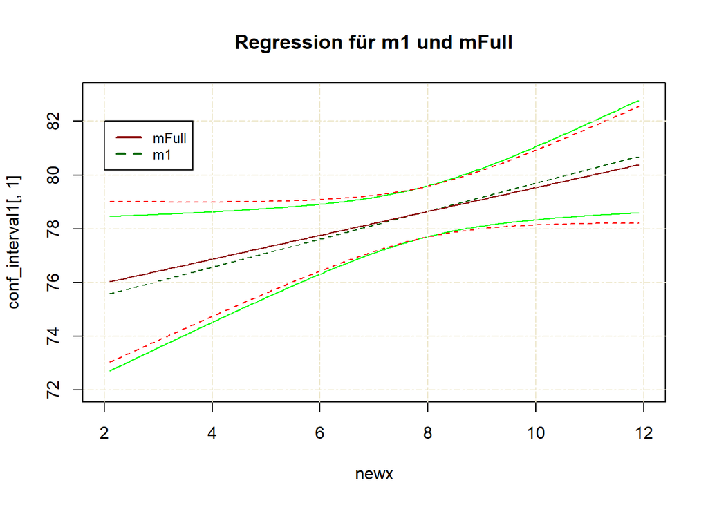

```r
# compute the models confidence interval and plot
newx = seq(min(completeData$HealthExp), max(completeData$HealthExp), by = 0.05)
conf_interval_Full <- predict(mFull, newdata = data.frame(HealthExp = newx, UrbPop = mean(completeData$UrbPop), Gini = mean(completeData$Gini)), interval = "confidence", level = 0.95)

plot(newx, conf_interval1[,1], col="darkgreen", type = 'l', lty=2, xlim=c(2, 12), ylim=c(72, 83), main="Regression für m1 und mFull")
lines(newx, conf_interval1[,2], col="green", lty=1)
lines(newx, conf_interval1[,3], col="green", lty=1)


lines(newx, conf_interval_Full[,1], col="darkred", lty=1)
lines(newx, conf_interval_Full[,2], col="red", lty=2)
lines(newx, conf_interval_Full[,3], col="red", lty=2)

grid (NULL,NULL, lty = 6, col = "cornsilk2")
legend(2, 82, legend = c("mFull", "m1"),
       col = c("darkred", "darkgreen"), lwd = 2, lty = 1:2, cex = 0.8)
```

#### Vergleich aller Modelle

```r
# Calculate AIC
AIC(m0)
```

```
## [1] 305.5895
```

```r
AIC(m1)
```

```
## [1] 292.2751
```

```r
AIC(mFull)
```

```
## [1] 293.0569
```

```r
# test if with both covariates is any better
summary(mFull)
```

```
##
## Call:
## lm(formula = formulaFull, data = completeData)
##
## Residuals:
##     Min      1Q  Median      3Q     Max
## -7.8401 -1.8685 -0.2992  2.2041  8.2199
##
## Coefficients:
##             Estimate Std. Error t value Pr(>|t|)
## (Intercept) 69.96754    4.44938  15.725  < 2e-16 ***
## HealthExp    0.44416    0.24329   1.826 0.073885 .
## UrbPop       0.12376    0.03102   3.990 0.000216 ***
## Gini        -0.10434    0.09769  -1.068 0.290621
## ---
## Signif. codes:  0 '***' 0.001 '**' 0.01 '*' 0.05 '.' 0.1 ' ' 1
##
## Residual standard error: 3.457 on 50 degrees of freedom
## Multiple R-squared:  0.3939, Adjusted R-squared:  0.3576
## F-statistic: 10.83 on 3 and 50 DF,  p-value: 1.351e-05
```

```r
anova(m0, m1, mFull)
```

```
## Analysis of Variance Table
##
## Model 1: LifeExp ~ HealthExp
## Model 2: LifeExp ~ HealthExp + UrbPop
## Model 3: LifeExp ~ HealthExp + UrbPop + Gini
##   Res.Df    RSS Df Sum of Sq       F    Pr(>F)
## 1     52 811.64
## 2     51 611.22  1   200.420 16.7691 0.0001542 ***
## 3     50 597.59  1    13.634  1.1408 0.2906213
## ---
## Signif. codes:  0 '***' 0.001 '**' 0.01 '*' 0.05 '.' 0.1 ' ' 1
```

Das hinzufügen des Gini Indexes hat die Prognose der Lebenserwartung nicht signifikant verbessert, da sowohl die Unterschiede der Regressionslinien gering sind, als auch der $r^{2}$ Wert sich von *m1* zu *mFull* nicht geändert hat. Somit kann das Modell mFull, zugunsten des Modelles *m1* verworfen werden.

Die Nullhypothese $H_0^{mFull}$ wurde somit bestätigt.

#### Zusammenfassung

Mit den vorliegenden Daten kann ein Zusammenhang zwischen der durchschnittlichen Lebenserwartung und den Gesundheitsausgaben eines Landes gezeigt werden. Durch die Einbeziehung des urbanen Bevölkerungsanteiles, konnte die Varianz der Daten verringert und die Genauigkeit des Modells erhöht werden.

#### Ausblick

Da im WHO Bericht weitere Daten vorhanden sind, kann die Analyse auf weitere mögliche Faktoren ausgeweitet werden. Zusätzlich kann durch das Hinzufügen weiterer Daten (z.B. Core Health Indicators für die Jahre 2012 bis 2016) das Modell um zufällige Effekte (z.B. Jahr) erweitert werden, um die Datenbasis und die Modellgenauigkeit bezüglich der oberen Fragestellung zu erhöhen.